# Lecture 5

Spatial interpolation: simple approaches

2024-11-12

## Time series versus spatial data

Differences:

- spatial data live in 2 (or 3) dimensions
- there’s no past and future
- there’s no simple conditional independence (AR)

Correspondences

- nearby observations are more alike (auto-correlation)
- we can form moving averages
- coordinate reference systems are a bit like time zones and DST

## Spatial modelling and spatial interpolation

**What´s next?**

- Simple ways of interpolation
- Simple statistical models for interpolation
- Geostatistical interpolation
- Deterministic models
- Combined approaches

## Taking a step back

Why do we need models?

- to understand *relations* or *processes*
- to assess (predict, forcast, map) something we do or did not measure *and cannot see*
- to assess the consequence of decisions (scenarios) where we cannot measure

## What information do we have?

- We have measurements $Z(x)$, with $x$ two-dimensional (location on the map)
- we have $x$ and $y$
- we may have land use data
- we may have soil type or geological data
- we may have remote sensing imagery
- we may have all kinds of relevant information, related to processes that cause (or result from) $Z(x)$
- we have google maps and other tiled web map sources

*We don’t want to ignore anything important*

## A sample dataset

The `meuse` dataset is loaded from package **sp**:

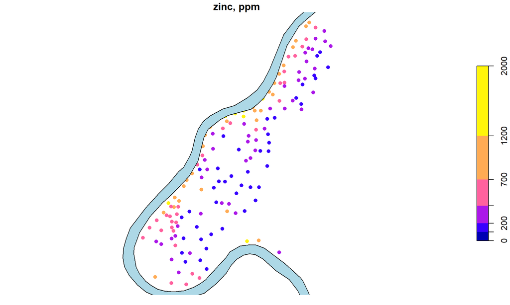

## Thiessen “polygons”, Nearest Neighbour

1-Neareast neighbour interpolation:

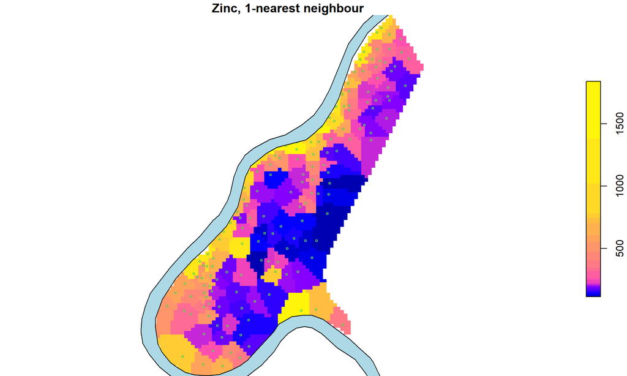

## Zinc concentration vs. distance to river

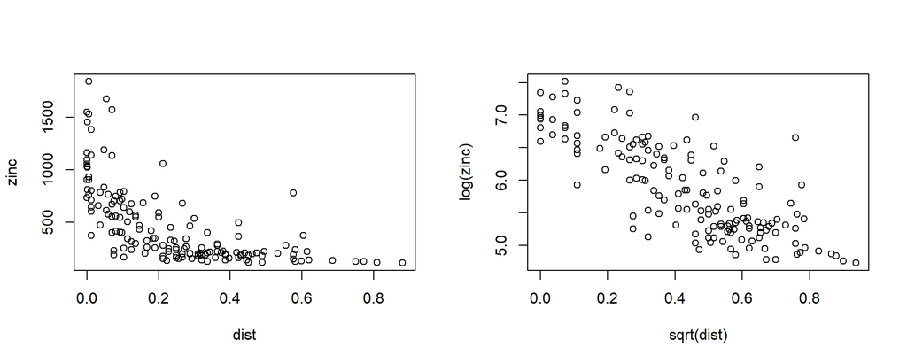

```r
par(mfrow=c(1,2))
plot(zinc~dist, meuse)
plot(log(zinc)~sqrt(dist), meuse)
```

## Zinc concentration vs. distance to river

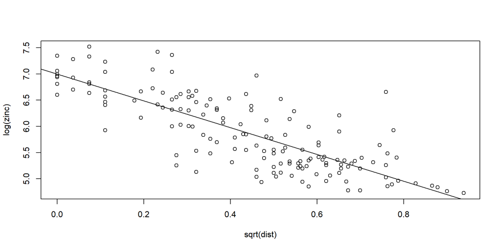

```r
plot(log(zinc)~sqrt(dist), meuse.sf)
abline(lm(log(zinc) ~ sqrt(dist), meuse.sf))
```

## Zinc conc. vs. distance to river

Map of distance to river

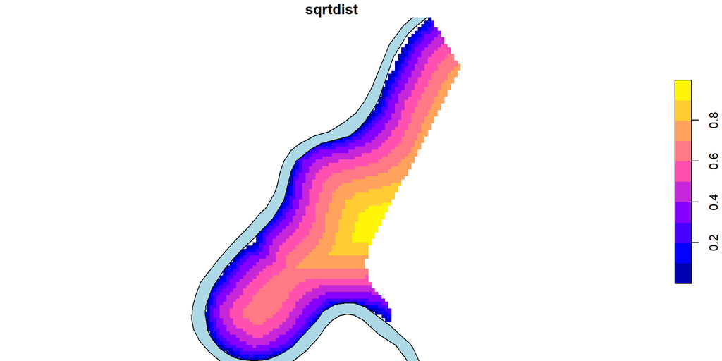

```r
meuse.grid$sqrtdist = sqrt(meuse.grid$dist)
plot(meuse.grid["sqrtdist"], col = sf.colors(), breaks = "equal",reset = FALSE)
plot(meuse.sr, col = "lightblue", add = TRUE)
```

## Zinc conc. vs. distance to river

Linear trend

```r
lm(log(zinc)~sqrt(dist),meuse)
```

```
Call:
lm(formula = log(zinc) ~ sqrt(dist), data = meuse)

Coefficients:
(Intercept)   sqrt(dist)
      6.994       -2.549
```

## Zinc conc. vs. distance to river

Map of linear trend

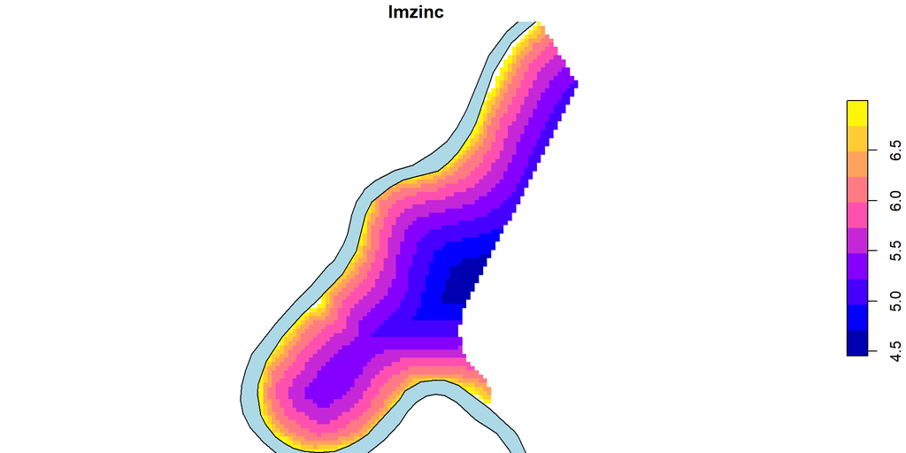

```r
meuse.grid$lmzinc = 6.994 - 2.549*sqrt(meuse.grid$dist)
plot(meuse.grid["lmzinc"], col = sf.colors(), breaks = "equal",reset = FALSE)
plot(meuse.sr, col = "lightblue", add = TRUE)
```

## Inverse distance weighted interpolation

Uses a **weighted** average:
$$\hat{Z}(s_0) = \sum_{i=1}^n \lambda_i Z(s_i)$$

with $s_0 = \{x_0, y_0\}$, or $s_0 = \{x_0, y_0, \mbox{depth}_0\}$ weights inverse proportional to power $p$ of distance:
$$\lambda_i = \frac{|s_i-s_0|^{-p}}{\sum_{i=1}^n |s_i-s_0|^{-p}}$$

- power $p$: tuning parameter
- if for some $i$, $|s_i-s_0| = 0$, then $\lambda_i = 1$ and other weights become zero
- $\Rightarrow$ **exact** interpolator

## Inverse distance weighted interpolation of log(zinc)

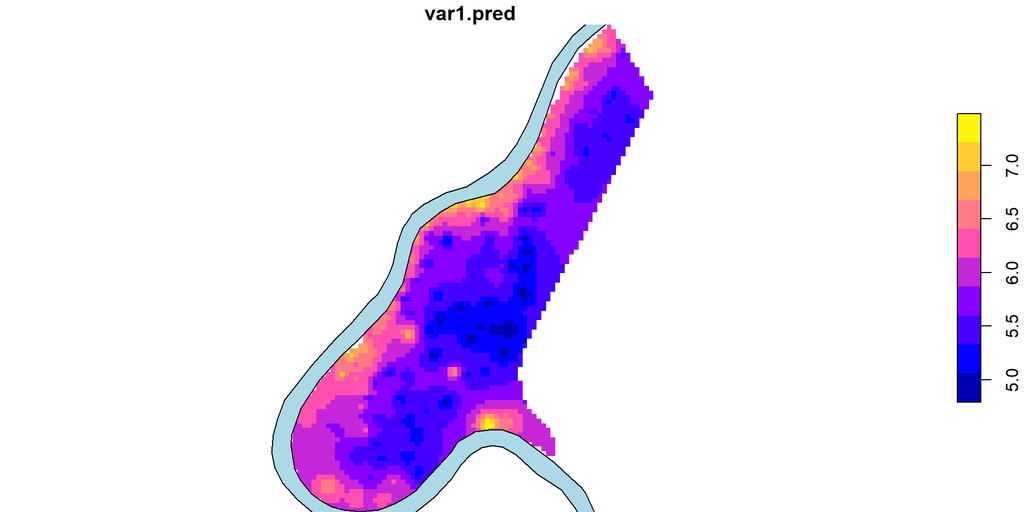

```r
lzn.tp = idw(log(zinc) ~ 1, meuse.sf, meuse.grid)
plot(lzn.tp, col = sf.colors(), breaks = "equal", reset = FALSE)
plot(meuse.sr, col = "lightblue", add = TRUE)
```

## Effect of power $p$

$$\hat{Z}(s_0) = \sum_{i=1}^n \lambda_i Z(s_i)$$

$$\lambda_i = \frac{|s_i-s_0|^{-p}}{\sum_{i=1}^n |s_i-s_0|^{-p}}$$

- the power $p$ determines the influence of distance during the interpolation

## Effect of power $p$

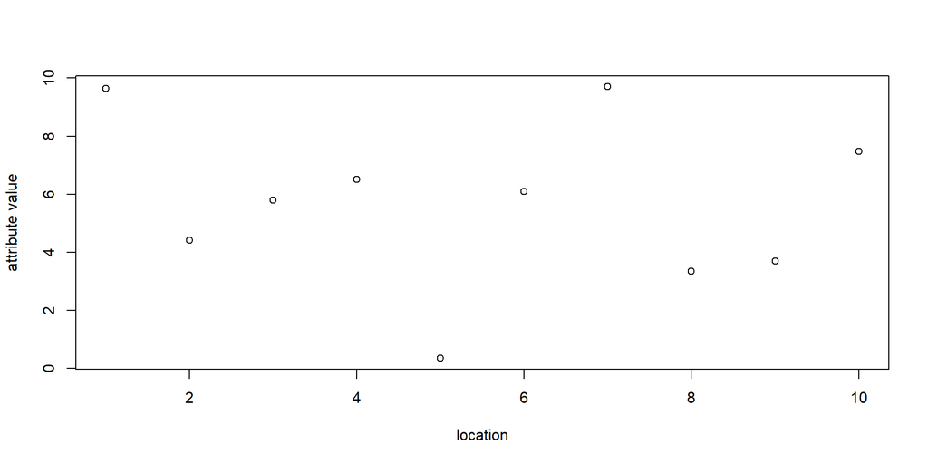

## Effect of power $p$

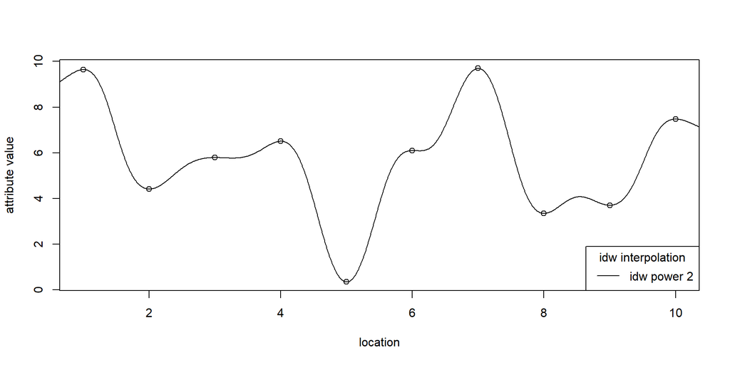

## Effect of power $p$

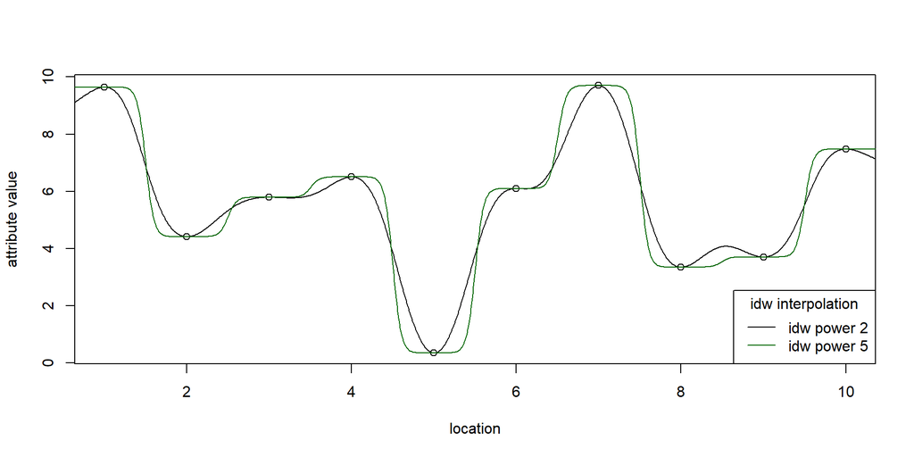

## Effect of power $p$

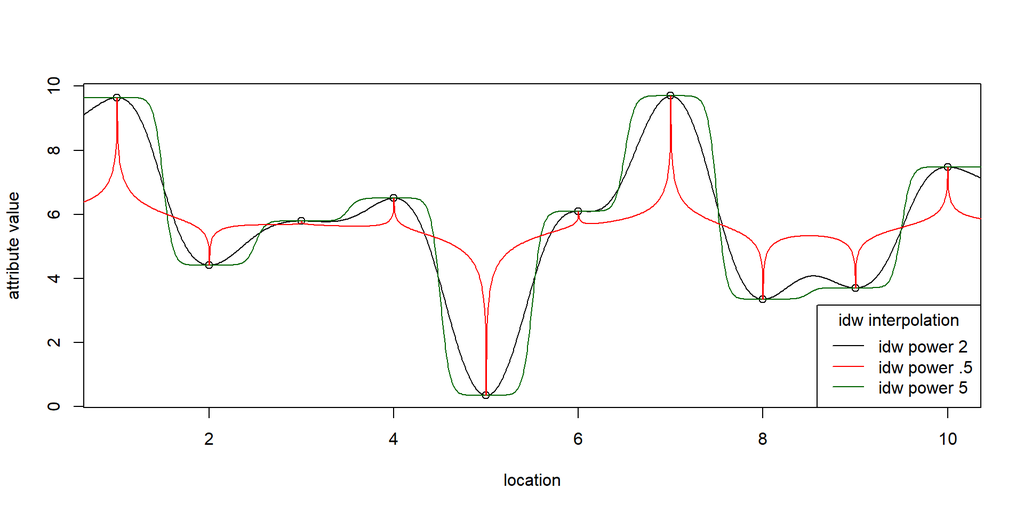

## Effect of power $p$

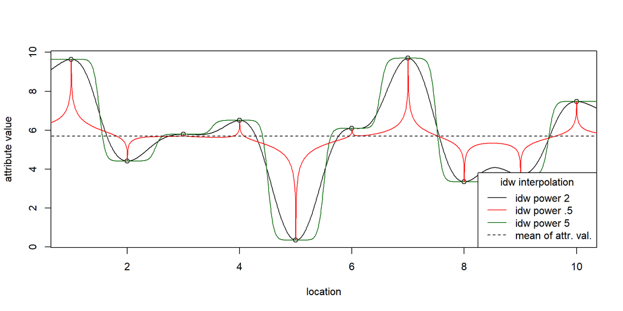

## IDW of log(zinc) power 2 vs power 5

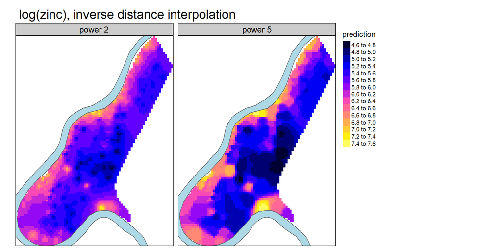

## Inverse distance weighted interpolation

- idw estimates values as weighted sums of values at surrounding locations
- spatial dependencies between values are only estimated according to distance
- using geostatistical interpolation methods these dependencies can be quantified

## Simple statistical models for interpolation

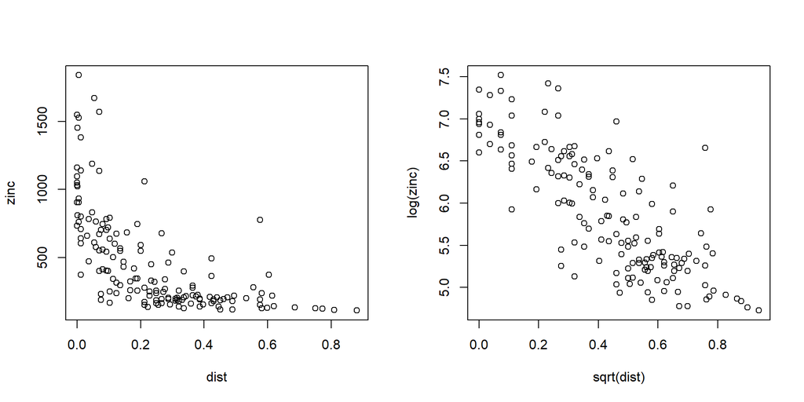

## Simple statistical models for interpolation

- in the previous example, we did not really take space (in terms of the location of measurements) into account
- we simply used a linear model with a predictor variable, which in this case carried spatial information (distance to the river)
- we will now use multiple linear regression with polynomials of coordinates as predictor variables –> trend surface analysis
- imagine trying to fit a plane to a number of points in 3 dimensions $(x,y,z)$ where $z$ is the dependent variable (the attribute that we want to predict), this would be a first degree trend surface

## Spatial regression - compare to sample data set

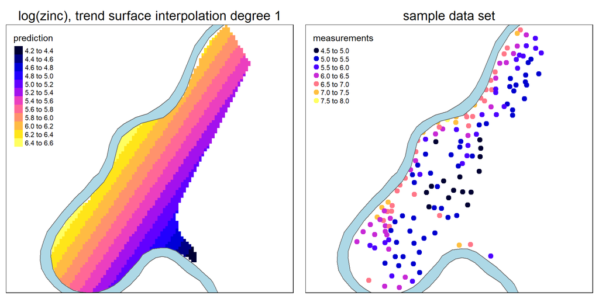

## Spatial regression - compare to sample data set

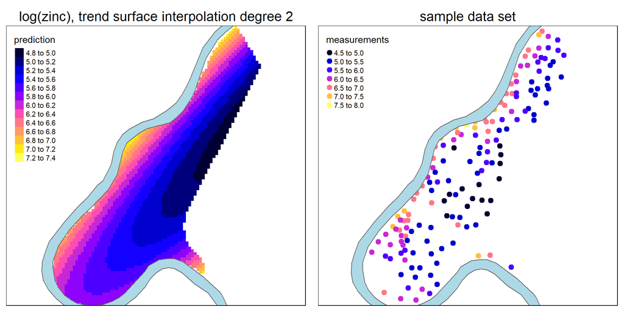

## Regression or correlation?

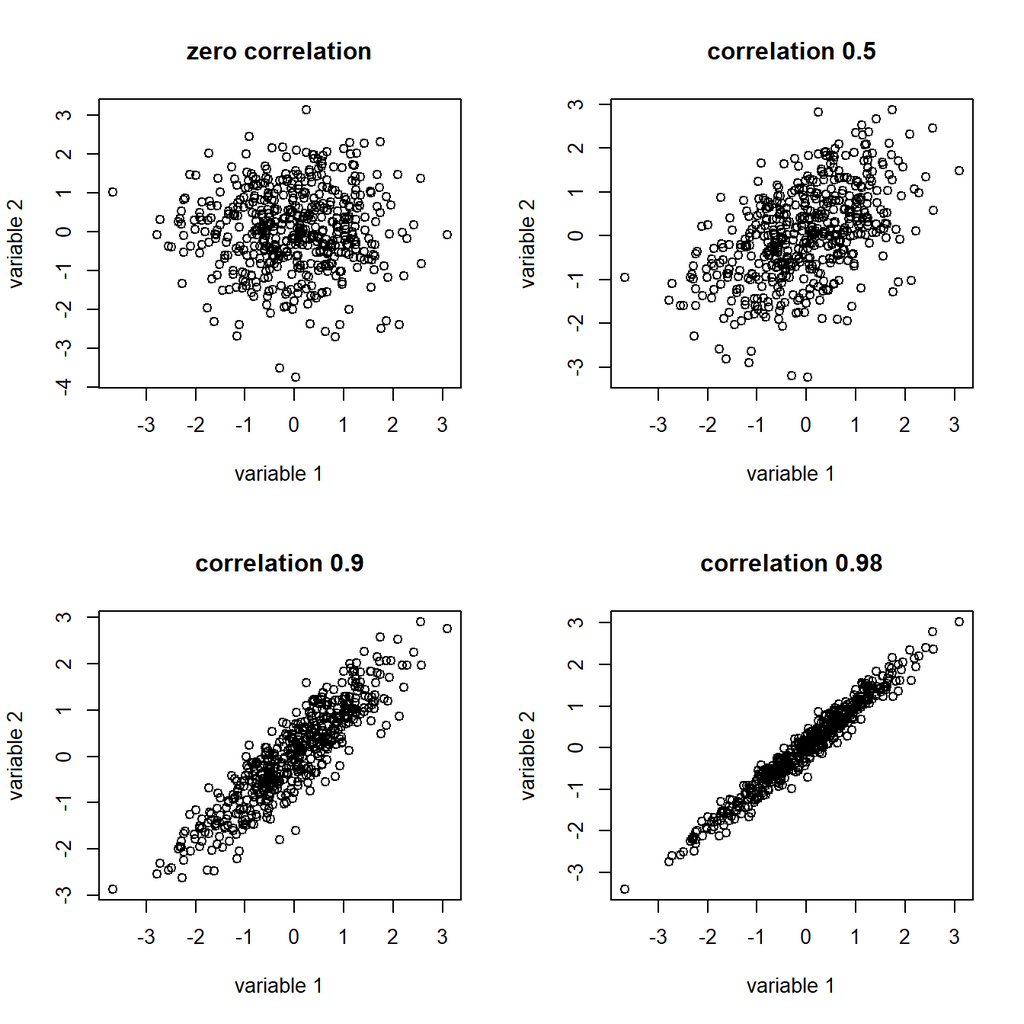

## Correlation vs. regression:

Correspondences:

- both are in the “classic statistics” book, and may involve hypothesis testing
- both deal with *two* continuous variables
- both look at (first order) *linear* relations
- when correlation is significant, the regression *slope* is significant

## Correlation vs. regression:

Differences:

- Regression distinguishes $y$ from $x$: $y$ depends on $x$, not reverse;
- the line $y=ax+b$ is *not* equal to the line $x = cy + d$
- Correlation is symmetric: $\text{Corr}(x,y)=\text{Corr}(y,x)$
- Correlation coefficient is unitless and within $[-1,1]$, regression coeficients have data units
- Regression is concerned with *prediction* of $y$ from $x$.

## The power of regression models for spatial prediction

… is hard to overestimate. Regression and correlation are the fork and knife of statistics.

- linear models have endless application: polynomials, interactions, nested effects, ANOVA/ANCOVA models, hypothesis testing, lack of fit testing, …
- predictors can be transformed non-linearly
- linear models can be generalized: logistic regression, Poisson regression, …, to cope with discrete data (0/1 data, counts, log-normal)
- many derived techniques solve one particular issue in regression, e.g.:
  - ridge regression solves collinearity (extreme correlation among predictors)
  - stepwise regression automatically selects “best” models among many candidates
  - classification and regression trees

## Why is regression difficult in spatial problems?

Regression models assume independent observations. Spatial data are always to some degree spatially correlated.

This does not mean we should discard regression, but rather think about

- to which extent is an outcome dependent on independence?
- to which extent is regression *robust* agains a violated assumption of independent observations?
- to which extent *is* the assumption violated? (how strong is the correlation)

## What is spatial correlation?

Waldo Tobler’s first “law” in geography: *“Everything is related to everything else, but near things are more related than distant things.”* [Tobler, 1970, p.236]*

Setting aside whether Tobler was the first to acknowledge this, and also whether the expression can be called a “law”, we wonder how *being related* can be expressed?

*TOBLER, W. R. (1970). “A computer model simulation of urban growth in the Detroit region”. Economic Geography, 46(2): 234-240.